# Customer Segmentation : Online Retail Dataset

## by: Mohamed Eltedawy

# Data Preprocessing

```python
#Importing important libraries
import pandas as pd
import numpy as np
from scipy import stats
import datetime as dt
import seaborn as sns
import matplotlib.pyplot as plt
import warnings
from sklearn.preprocessing import StandardScaler
from sklearn.cluster import KMeans
from mpl_toolkits.mplot3d import Axes3D


plt.figure(figsize=[12,12])
%matplotlib inline
plt.style.use('ggplot')
warnings.filterwarnings('ignore')
```

```python
df = pd.read_excel('Online Retail.xlsx')
df.head()
```

|  | InvoiceNo | StockCode | Description | Quantity | InvoiceDate | UnitPrice | CustomerID | Country |
| --- | --- | --- | --- | --- | --- | --- | --- | --- |
| 0 | 536365 | 85123A | WHITE HANGING HEART T-LIGHT HOLDER | 6 | 2010-12-01 08:26:00 | 2.55 | 17850.0 | United Kingdom |
| 1 | 536365 | 71053 | WHITE METAL LANTERN | 6 | 2010-12-01 08:26:00 | 3.39 | 17850.0 | United Kingdom |
| 2 | 536365 | 84406B | CREAM CUPID HEARTS COAT HANGER | 8 | 2010-12-01 08:26:00 | 2.75 | 17850.0 | United Kingdom |
| 3 | 536365 | 84029G | KNITTED UNION FLAG HOT WATER BOTTLE | 6 | 2010-12-01 08:26:00 | 3.39 | 17850.0 | United Kingdom |
| 4 | 536365 | 84029E | RED WOOLLY HOTTIE WHITE HEART. | 6 | 2010-12-01 08:26:00 | 3.39 | 17850.0 | United Kingdom |

```python
#datatype of columns
df.info()
```

```
<class 'pandas.core.frame.DataFrame'>
RangeIndex: 541909 entries, 0 to 541908
Data columns (total 8 columns):
 #   Column       Non-Null Count   Dtype
---  ------       --------------   -----
 0   InvoiceNo    541909 non-null  object
 1   StockCode    541909 non-null  object
 2   Description  540455 non-null  object
 3   Quantity     541909 non-null  int64
 4   InvoiceDate  541909 non-null  datetime64[ns]
 5   UnitPrice    541909 non-null  float64
 6   CustomerID   406829 non-null  float64
 7   Country      541909 non-null  object
dtypes: datetime64[ns](1), float64(2), int64(1), object(4)
memory usage: 33.1+ MB
```

```python
#missing values
df.isnull().sum()
```

```
InvoiceNo           0
StockCode           0
Description      1454
Quantity            0
InvoiceDate         0
UnitPrice           0
CustomerID     135080
Country             0
dtype: int64
```

```python
#percentage of missing values
missing_values = pd.DataFrame(round(100*(df.isnull().sum())/df.shape[0],2),\
                              columns=['Percentage']).sort_values(by='Percentage',ascending=False)
missing_values
```

|  | Percentage |
| --- | --- |
| CustomerID | 24.93 |
| Description | 0.27 |
| InvoiceNo | 0.00 |
| StockCode | 0.00 |
| Quantity | 0.00 |
| InvoiceDate | 0.00 |
| UnitPrice | 0.00 |
| Country | 0.00 |

```python
#add new binary column for missing values in customer ID column, and copy this data to new one
df['id_null'] = pd.DataFrame(np.where(df['CustomerID'].isnull(),1,0))
df_id_null = df.copy()
```

```python
#Formatting
df['Description'] = df['Description'].str.replace('.','').str.upper().str.strip()
df['Description'] = df['Description'].replace('\s+',' ',regex=True)
df['Country'] = df['Country'].str.upper()
df.head()
```

|  | InvoiceNo | StockCode | Description | Quantity | InvoiceDate | UnitPrice | CustomerID | Country | id_null |
| --- | --- | --- | --- | --- | --- | --- | --- | --- | --- |
| 0 | 536365 | 85123A | WHITE HANGING HEART T-LIGHT HOLDER | 6 | 2010-12-01 08:26:00 | 2.55 | 17850.0 | UNITED KINGDOM | 0 |
| 1 | 536365 | 71053 | WHITE METAL LANTERN | 6 | 2010-12-01 08:26:00 | 3.39 | 17850.0 | UNITED KINGDOM | 0 |
| 2 | 536365 | 84406B | CREAM CUPID HEARTS COAT HANGER | 8 | 2010-12-01 08:26:00 | 2.75 | 17850.0 | UNITED KINGDOM | 0 |
| 3 | 536365 | 84029G | KNITTED UNION FLAG HOT WATER BOTTLE | 6 | 2010-12-01 08:26:00 | 3.39 | 17850.0 | UNITED KINGDOM | 0 |
| 4 | 536365 | 84029E | RED WOOLLY HOTTIE WHITE HEART | 6 | 2010-12-01 08:26:00 | 3.39 | 17850.0 | UNITED KINGDOM | 0 |

**From the describition of dataset,** the stockCode column contain 5-digits to each distinct product

```python
#check unvalid values in stockcode column
unvalid_code = df['StockCode'].astype(str).unique()
unvalid_code.sort()
list(unvalid_code[::-1][:5])
```

```
['m', 'gift_0001_50', 'gift_0001_40', 'gift_0001_30', 'gift_0001_20']
```

But we found lots of unvalide stock code, we will rid of it.

```python
#take only first 5 digits
df = df.loc[df['StockCode'].astype(str).str[0:5].str.isdigit()]
```

```python
#descriptive statistics for quantitative columns
df.describe()
```

|  | Quantity | UnitPrice | CustomerID | id_null |
| --- | --- | --- | --- | --- |
| count | 538914.000000 | 538914.000000 | 404909.000000 | 538914.000000 |
| mean | 9.586116 | 3.268824 | 15295.168304 | 0.248657 |
| std | 218.631895 | 4.492279 | 1710.424057 | 0.432235 |
| min | -80995.000000 | 0.000000 | 12346.000000 | 0.000000 |
| 25% | 1.000000 | 1.250000 | 13969.000000 | 0.000000 |
| 50% | 3.000000 | 2.080000 | 15159.000000 | 0.000000 |
| 75% | 10.000000 | 4.130000 | 16794.000000 | 0.000000 |
| max | 80995.000000 | 649.500000 | 18287.000000 | 1.000000 |

**From the describtion of dataset,** we found that there are some canceled transactions, and these canceled transactions presented in invoiceno column and begin with 'C', so we will explore this column because maybe these canceled transactions were recorded as negative.

```python
#Take only values which start with letter 'C' in InoviceNo column
cancel_trans = df[df['InvoiceNo'].astype(str).str.contains('C')]
cancel_trans.head()
```

|  | InvoiceNo | StockCode | Description | Quantity | InvoiceDate | UnitPrice | CustomerID | Country | id_null |
| --- | --- | --- | --- | --- | --- | --- | --- | --- | --- |
| 154 | C536383 | 35004C | SET OF 3 COLOURED FLYING DUCKS | -1 | 2010-12-01 09:49:00 | 4.65 | 15311.0 | UNITED KINGDOM | 0 |
| 235 | C536391 | 22556 | PLASTERS IN TIN CIRCUS PARADE | -12 | 2010-12-01 10:24:00 | 1.65 | 17548.0 | UNITED KINGDOM | 0 |
| 236 | C536391 | 21984 | PACK OF 12 PINK PAISLEY TISSUES | -24 | 2010-12-01 10:24:00 | 0.29 | 17548.0 | UNITED KINGDOM | 0 |
| 237 | C536391 | 21983 | PACK OF 12 BLUE PAISLEY TISSUES | -24 | 2010-12-01 10:24:00 | 0.29 | 17548.0 | UNITED KINGDOM | 0 |
| 238 | C536391 | 21980 | PACK OF 12 RED RETROSPOT TISSUES | -24 | 2010-12-01 10:24:00 | 0.29 | 17548.0 | UNITED KINGDOM | 0 |

```python
cancel_trans.query("Quantity > 0")
```

|  | InvoiceNo | StockCode | Description | Quantity | InvoiceDate | UnitPrice | CustomerID | Country | id_null |
| --- | --- | --- | --- | --- | --- | --- | --- | --- | --- |

```python
print("Number of cancelled transactions:", cancel_trans.shape[0])
print("Total number of transactions with negative quantity:", df[df['Quantity'] <= 0 ]['Quantity'].count())
```

```
Number of cancelled transactions: 8704
Total number of transactions with negative quantity: 10028
```

From the canceled transactions, we can see that there are 8704 transactions were canceled, so they having negative values in Quantity column.

But still we have 1324 negative transaction and not recorded as canceled but have negative quantity.

```python
print("Number of transactions with zero price or less and neg quantity:",\
      df.query("UnitPrice <= 0 and Quantity <0").shape[0])
```

```
Number of transactions with zero price or less and neg quantity: 1324
```

```python
#cleaned data with Quantity and unitprice greater than 0 and negative numbers
df = df.query("Quantity > 0 & UnitPrice > 0")
df.head()
```

|  | InvoiceNo | StockCode | Description | Quantity | InvoiceDate | UnitPrice | CustomerID | Country | id_null |
| --- | --- | --- | --- | --- | --- | --- | --- | --- | --- |
| 0 | 536365 | 85123A | WHITE HANGING HEART T-LIGHT HOLDER | 6 | 2010-12-01 08:26:00 | 2.55 | 17850.0 | UNITED KINGDOM | 0 |
| 1 | 536365 | 71053 | WHITE METAL LANTERN | 6 | 2010-12-01 08:26:00 | 3.39 | 17850.0 | UNITED KINGDOM | 0 |
| 2 | 536365 | 84406B | CREAM CUPID HEARTS COAT HANGER | 8 | 2010-12-01 08:26:00 | 2.75 | 17850.0 | UNITED KINGDOM | 0 |
| 3 | 536365 | 84029G | KNITTED UNION FLAG HOT WATER BOTTLE | 6 | 2010-12-01 08:26:00 | 3.39 | 17850.0 | UNITED KINGDOM | 0 |
| 4 | 536365 | 84029E | RED WOOLLY HOTTIE WHITE HEART | 6 | 2010-12-01 08:26:00 | 3.39 | 17850.0 | UNITED KINGDOM | 0 |

```python
df.describe()
```

|  | Quantity | UnitPrice | CustomerID | id_null |
| --- | --- | --- | --- | --- |
| count | 527725.000000 | 527725.000000 | 396337.000000 | 527725.000000 |
| mean | 10.567997 | 3.265320 | 15301.689416 | 0.248971 |
| std | 155.839274 | 4.377915 | 1709.961948 | 0.432417 |
| min | 1.000000 | 0.040000 | 12346.000000 | 0.000000 |
| 25% | 1.000000 | 1.250000 | 13975.000000 | 0.000000 |
| 50% | 3.000000 | 2.080000 | 15159.000000 | 0.000000 |
| 75% | 11.000000 | 4.130000 | 16803.000000 | 0.000000 |
| max | 80995.000000 | 649.500000 | 18287.000000 | 1.000000 |

Minimum for Quantity and Unit Price are more than zero, and this makes sense.

```python
df.isnull().sum()
```

```
InvoiceNo           0
StockCode           0
Description         0
Quantity            0
InvoiceDate         0
UnitPrice           0
CustomerID     131388
Country             0
id_null             0
dtype: int64
```

After omitting the above value, description values also dropped.

In this dataset, there are some rows that the same products have different 'UnitPrice'. This could come from the fact that there might be some discounts for some products or some special conditions for specific customers.

So for the sake of this demonstration, we assume that these values are incorrect due to input errors or human mistakes and for each product we use the mode value of its 'UnitPrice'.

```python
#extract data for specific stockcode
df.query("StockCode == 21915").tail()
```

|  | InvoiceNo | StockCode | Description | Quantity | InvoiceDate | UnitPrice | CustomerID | Country | id_null |
| --- | --- | --- | --- | --- | --- | --- | --- | --- | --- |
| 490376 | 578045 | 21915 | RED HARMONICA IN BOX | 1 | 2011-11-22 14:43:00 | 1.25 | 17297.0 | UNITED KINGDOM | 0 |
| 492426 | 578118 | 21915 | RED HARMONICA IN BOX | 8 | 2011-11-23 10:08:00 | 1.25 | 12955.0 | UNITED KINGDOM | 0 |
| 494348 | 578270 | 21915 | RED HARMONICA IN BOX | 10 | 2011-11-23 13:39:00 | 2.46 | 14096.0 | UNITED KINGDOM | 0 |
| 520003 | 580243 | 21915 | RED HARMONICA IN BOX | 1120 | 2011-12-02 12:19:00 | 1.06 | 16333.0 | UNITED KINGDOM | 0 |
| 534835 | 581173 | 21915 | RED HARMONICA IN BOX | 2 | 2011-12-07 15:07:00 | 1.25 | 17870.0 | UNITED KINGDOM | 0 |

For the same product "RED HARMONICA IN BOX" in dataset we found that it has different unit price.

### Take longgggg Time

```python
#Incorrect Prices
StockList = df.StockCode.unique()
CalculatedMode = map(lambda x: df.UnitPrice[df.StockCode == x].mode()[0],StockList)
StockModes = list(CalculatedMode)
for i,v in enumerate(StockList):
    df.loc[df['StockCode']== v, 'UnitPrice'] = StockModes[i]
```

```python
#show unique customers in countries
customers = df.groupby('CustomerID')['Country'].unique()
customers.loc[customers.apply(lambda x:len(x)>1)].reset_index()
```

|  | CustomerID | Country |
| --- | --- | --- |
| 0 | 12370.0 | [CYPRUS, AUSTRIA] |
| 1 | 12394.0 | [BELGIUM, DENMARK] |
| 2 | 12417.0 | [BELGIUM, SPAIN] |
| 3 | 12422.0 | [AUSTRALIA, SWITZERLAND] |
| 4 | 12429.0 | [DENMARK, AUSTRIA] |
| 5 | 12431.0 | [AUSTRALIA, BELGIUM] |
| 6 | 12455.0 | [CYPRUS, SPAIN] |
| 7 | 12457.0 | [SWITZERLAND, CYPRUS] |

We found that there are duplicated values for Customer ID, the same customer id to different customers in different countries

We will replace the incorrect values with the mode value of the customer's country.

```python
df.query("CustomerID == 12370.0")[82:84]
```

|  | InvoiceNo | StockCode | Description | Quantity | InvoiceDate | UnitPrice | CustomerID | Country | id_null |
| --- | --- | --- | --- | --- | --- | --- | --- | --- | --- |
| 29814 | 538826 | 21380 | WOODEN HAPPY BIRTHDAY GARLAND | 12 | 2010-12-14 12:58:00 | 2.95 | 12370.0 | CYPRUS | 0 |
| 34293 | 539330 | 37449 | CERAMIC CAKE STAND + HANGING CAKES | 8 | 2010-12-17 09:38:00 | 9.95 | 12370.0 | AUSTRIA | 0 |

```python
#fixing Duplicated customers ID
for i,v in customers.items():
    if len(v)>1:
        df.Country[df['CustomerID'] == i] = df.Country[df['CustomerID'] == i].mode()[0]
```

Finalt Step at Processing is to remove missing values in customer id column

```python
df.isnull().sum()
```

```
InvoiceNo           0
StockCode           0
Description         0
Quantity            0
InvoiceDate         0
UnitPrice           0
CustomerID     131388
Country             0
id_null             0
dtype: int64
```

```python
data = df.dropna()
del data['id_null']
```

```python
data.isnull().sum()
```

```
InvoiceNo      0
StockCode      0
Description    0
Quantity       0
InvoiceDate    0
UnitPrice      0
CustomerID     0
Country        0
dtype: int64
```

Adding new column called revenue which calculate quantity * unirt price for each one

```python
data['revenue'] = data['UnitPrice'] * data['Quantity']
data = data[['InvoiceNo','CustomerID','StockCode','Description','InvoiceDate','Quantity','UnitPrice','revenue','Country']]
data.head()
```

|  | InvoiceNo | CustomerID | StockCode | Description | InvoiceDate | Quantity | UnitPrice | revenue | Country |
| --- | --- | --- | --- | --- | --- | --- | --- | --- | --- |
| 0 | 536365 | 17850.0 | 85123A | WHITE HANGING HEART T-LIGHT HOLDER | 2010-12-01 08:26:00 | 6 | 2.95 | 17.7 | UNITED KINGDOM |
| 1 | 536365 | 17850.0 | 71053 | WHITE METAL LANTERN | 2010-12-01 08:26:00 | 6 | 3.75 | 22.5 | UNITED KINGDOM |
| 2 | 536365 | 17850.0 | 84406B | CREAM CUPID HEARTS COAT HANGER | 2010-12-01 08:26:00 | 8 | 4.15 | 33.2 | UNITED KINGDOM |
| 3 | 536365 | 17850.0 | 84029G | KNITTED UNION FLAG HOT WATER BOTTLE | 2010-12-01 08:26:00 | 6 | 3.75 | 22.5 | UNITED KINGDOM |
| 4 | 536365 | 17850.0 | 84029E | RED WOOLLY HOTTIE WHITE HEART | 2010-12-01 08:26:00 | 6 | 4.25 | 25.5 | UNITED KINGDOM |

```python
#Extracting new features from the invoicedate column
data['month_name'] = data['InvoiceDate'].apply(lambda x: x.strftime('%B'))
data['month'] = data['InvoiceDate'].dt.month
data['year'] = data['InvoiceDate'].dt.year
data['month_year'] = pd.to_datetime(data[['year', 'month']].assign(Day=1))
data['WeekDay'] = data['InvoiceDate'].dt.day_name()
data['hour'] = data['InvoiceDate'].dt.hour
```

```python
data.head()
```

|  | InvoiceNo | CustomerID | StockCode | Description | InvoiceDate | Quantity | UnitPrice | revenue | Country | month_name | month | year | month_year | WeekDay | hour |
| --- | --- | --- | --- | --- | --- | --- | --- | --- | --- | --- | --- | --- | --- | --- | --- |
| 0 | 536365 | 17850.0 | 85123A | WHITE HANGING HEART T-LIGHT HOLDER | 2010-12-01 08:26:00 | 6 | 2.95 | 17.7 | UNITED KINGDOM | December | 12 | 2010 | 2010-12-01 | Wednesday | 8 |
| 1 | 536365 | 17850.0 | 71053 | WHITE METAL LANTERN | 2010-12-01 08:26:00 | 6 | 3.75 | 22.5 | UNITED KINGDOM | December | 12 | 2010 | 2010-12-01 | Wednesday | 8 |
| 2 | 536365 | 17850.0 | 84406B | CREAM CUPID HEARTS COAT HANGER | 2010-12-01 08:26:00 | 8 | 4.15 | 33.2 | UNITED KINGDOM | December | 12 | 2010 | 2010-12-01 | Wednesday | 8 |
| 3 | 536365 | 17850.0 | 84029G | KNITTED UNION FLAG HOT WATER BOTTLE | 2010-12-01 08:26:00 | 6 | 3.75 | 22.5 | UNITED KINGDOM | December | 12 | 2010 | 2010-12-01 | Wednesday | 8 |
| 4 | 536365 | 17850.0 | 84029E | RED WOOLLY HOTTIE WHITE HEART | 2010-12-01 08:26:00 | 6 | 4.25 | 25.5 | UNITED KINGDOM | December | 12 | 2010 | 2010-12-01 | Wednesday | 8 |

**Finally We cleaned our data, and it's ready for analysis**

```python
#Exporting cleaned data
#data.to_csv('cleaned_data.csv',index=False)
```

# EDA and Data Visulaization

We found that the percentage for missing values is big specially in customer id column so we will explore it more

We will see number of missing values of customer id in different countries, and which top 10 countries have most of them

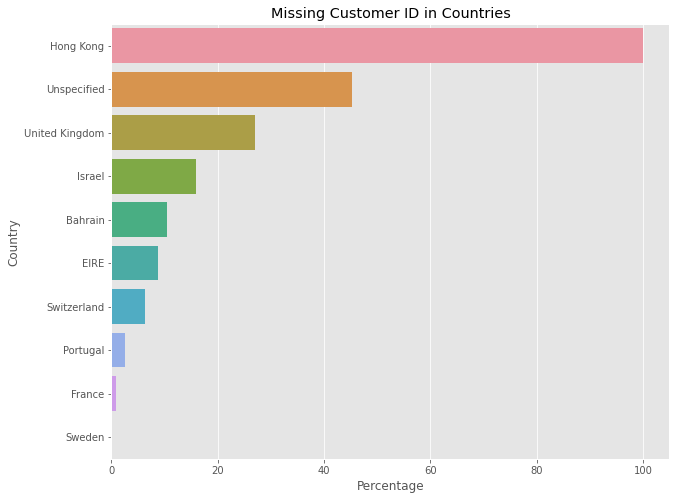

```python
#top 10 missing customers id in countries
null_id_by_country = pd.DataFrame(round(df_id_null.groupby('Country')['id_null'].mean()*100,2)).reset_index()
null_id_by_country.rename(columns={'id_null':'Percentage'},inplace=True)
top_null_countries_by_id = null_id_by_country.sort_values(by='Percentage',ascending=False).head(10)
plt.figure(figsize=[10,8])
sns.barplot(data=top_null_countries_by_id,y='Country',x='Percentage')
plt.title('Missing Customer ID in Countries')
plt.xlabel('Percentage')
plt.ylabel('Country')
plt.show()
```

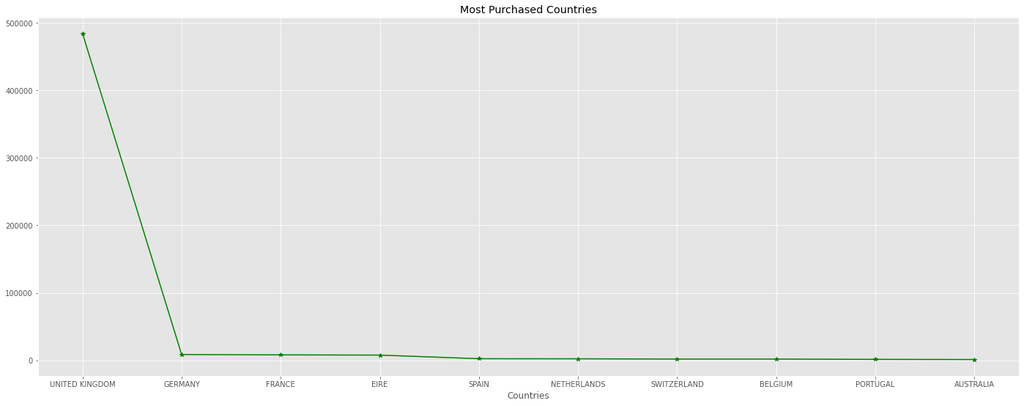

```python
most_purchased_bycountry = pd.DataFrame(df['Country'].value_counts().head(10))
#sns.set_style('whitegrid')
plt.figure(figsize=(24,9))
plt.plot(most_purchased_bycountry, 'g*-')
plt.title("Most Purchased Countries")
plt.xlabel('Countries')
plt.show()
```

UK is very higher than other countries as expected because it's UK based, so we will exclude it and visualize the rest of the countries.

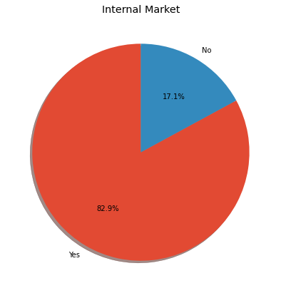

```python
#relation between internal market and external
fig = plt.figure(figsize=(25, 7))

data['Internal'] = data['Country'].apply(lambda x: 'Yes' if x=='UNITED KINGDOM' else 'No' )
market = data.groupby(["Internal"]).revenue.sum().sort_values(ascending = False)
plt.pie(market, labels=market.index, autopct='%1.1f%%', shadow=True, startangle=90)

plt.title('Internal Market')
plt.show()
```

Because of the online retail is UK-based, we can see the size for the internal market in it

```python
# group by the Country
countries = data.groupby('Country').sum()
```

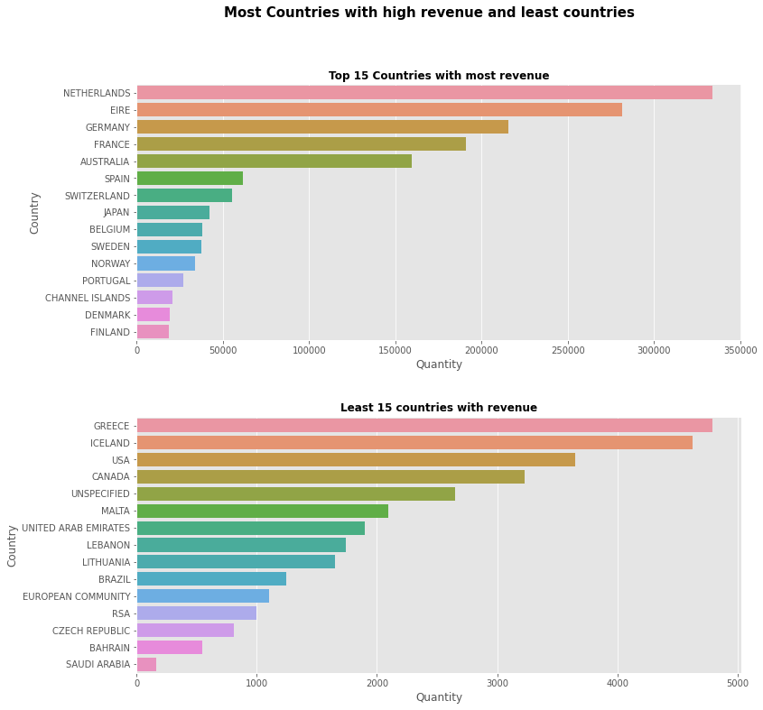

```python
# sort the value and get the first 15 after UK and least countries
countries_high = countries.sort_values(by = 'revenue',ascending = False)[1:16]
countries_high = countries_high.reset_index()
countries_low = countries.sort_values('revenue',ascending=False).tail(15)

fig,axs = plt.subplots(nrows=2, ncols=1, figsize = (12,12))
plt.subplots_adjust(hspace = 0.3)
fig.suptitle('Most Countries with high revenue and least countries', fontsize=15,fontweight = 'bold')
sns.barplot(x=countries_high.revenue, y=countries_high.Country, ax= axs[0]).set(xlabel='Quantity')
axs[0].set_title('Top 15 Countries with most revenue', size=12, fontweight = 'bold')

sns.barplot(x=countries_low.revenue, y=countries_low.index, ax= axs[1]).set(xlabel='Quantity')
axs[1].set_title('Least 15 countries with revenue', size=12, fontweight = 'bold')
plt.show()
```

We will see the countries which have big number of customers and the opposite countries, from this data we can see where our store is more active

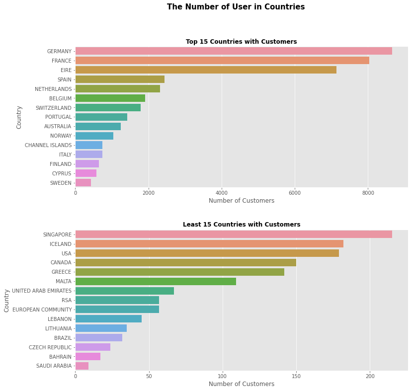

```python
countries_customers = data.groupby(['Country'])['CustomerID'].count()
countries_most_cust = countries_customers.sort_values(ascending=False).reset_index()[1:16]
countries_low_cust  = countries_customers.sort_values(ascending=False).reset_index().tail(15)

fig,axs = plt.subplots(nrows=2, ncols=1, figsize = (12,12))
plt.subplots_adjust(hspace = 0.3)
fig.suptitle('The Number of User in Countries', fontsize=15,fontweight = 'bold')

sns.barplot(x=countries_most_cust.CustomerID, y=countries_most_cust.Country, ax= axs[0]).set(xlabel='Number of Customers')
axs[0].set_title('Top 15 Countries with Customers', size=12, fontweight = 'bold')

sns.barplot(x=countries_low_cust.CustomerID, y=countries_low_cust.Country, ax= axs[1]).set(xlabel='Number of Customers')
axs[1].set_title('Least 15 Countries with Customers', size=12, fontweight = 'bold')
plt.show()
```

We will see the most selling products over all the dataset

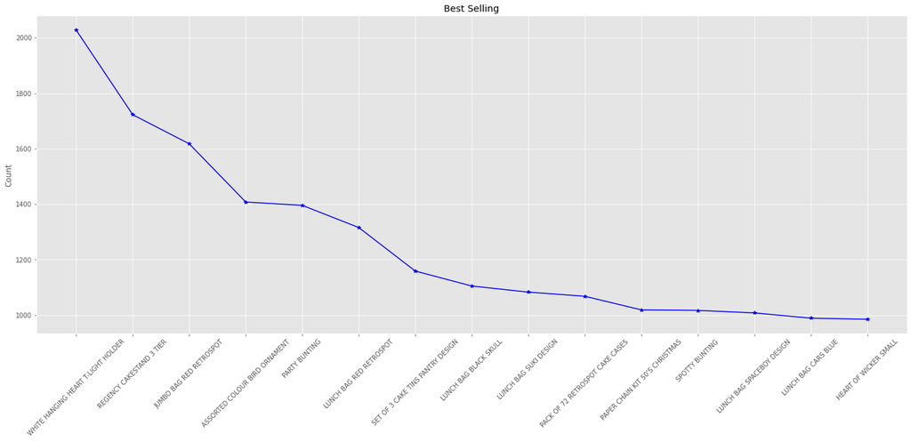

```python
most_purchased_prods = pd.DataFrame(data['Description'].value_counts().head(15))

plt.figure(figsize=(24,9))
plt.xticks(rotation=45)
plt.plot(most_purchased_prods, 'b*-')
plt.title('Best Selling')
plt.ylabel('Count')
plt.show()
```

We will see the most sold products and see the amount that sold and the revenue for these products

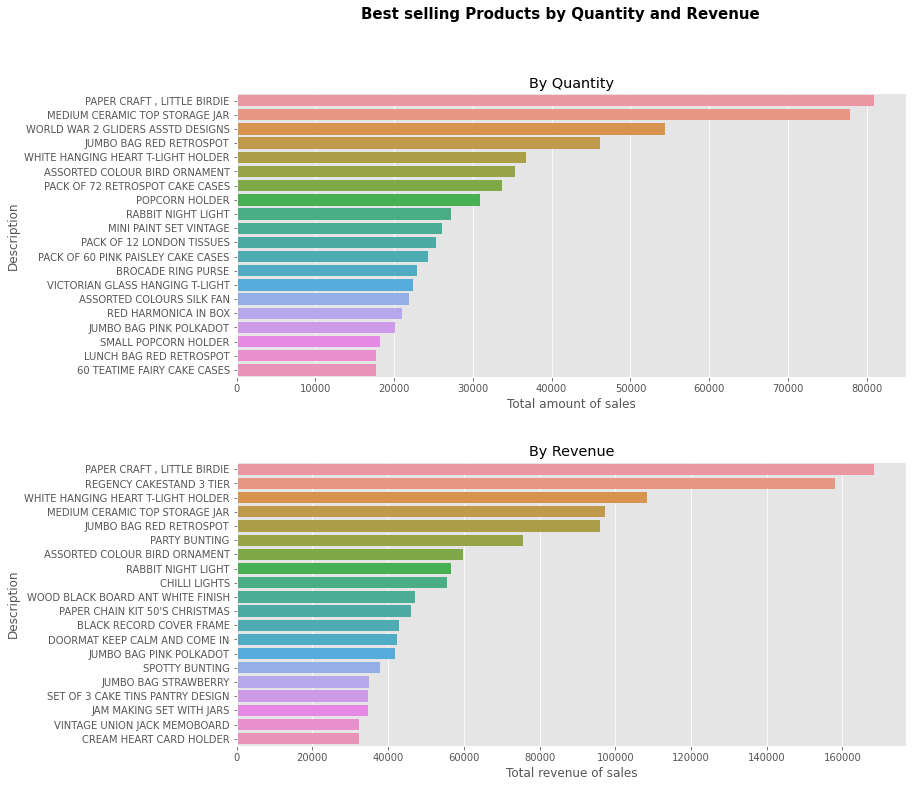

```python
top20prod_quan = data.groupby('Description')['Quantity'].sum().sort_values(ascending=False)[:20].reset_index()
top20prod_rev = data.groupby('Description')['revenue'].sum().sort_values(ascending=False)[:20].reset_index()

fig,axs = plt.subplots(nrows=2, ncols=1, figsize = (12,12))
plt.subplots_adjust(hspace = 0.3)
fig.suptitle('Best selling Products by Quantity and Revenue', fontsize=15,fontweight = 'bold')

sns.barplot(x=top20prod_quan.Quantity,y=top20prod_quan.Description,ax=axs[0]).set_xlabel('Total amount of sales')
axs[0].set_title('By Quantity')

sns.barplot(x=top20prod_rev.revenue,y=top20prod_rev.Description,ax=axs[1]).set_xlabel('Total revenue of sales')
axs[1].set_title('By Revenue')
plt.show()
```

We will explore the most reterned products

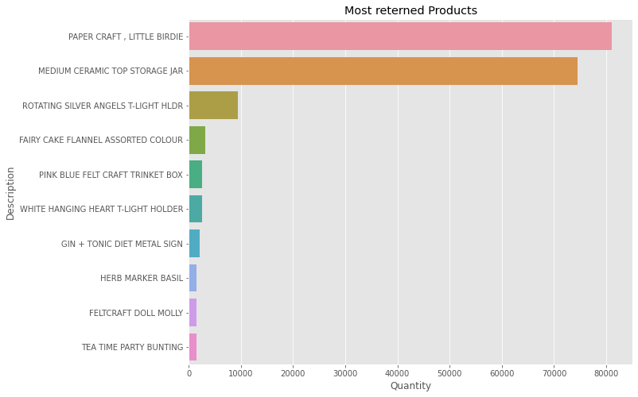

```python
reterned_item = cancel_trans[cancel_trans['Quantity']< 0 ].groupby('Description')['Quantity']\
                    .sum().abs().sort_values(ascending=False).reset_index()[:10]

plt.figure(figsize=[10,8])
sns.barplot(x=reterned_item.Quantity,y=reterned_item.Description)
plt.title('Most reterned Products')
plt.xlabel('Quantity')
plt.ylabel('Description')
plt.show()
```

```python
#plotting the qunatity vs unitprice
#Corr = sns.jointplot(x="Quantity", y="UnitPrice", data = data, height = 7)
#Corr.fig.suptitle("UnitPrice and Quantity Comparison", fontsize = 15, y = 1.1)
#plt.show()
```

**We will explore the InvoiceDate column and extract insight from it**

In the next figure we will see the number of orders per every month and see that November is the highest one

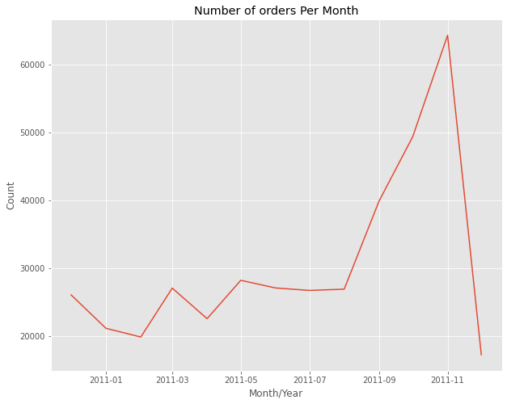

```python
order_per_month = pd.DataFrame(data.groupby(['month_year'])['InvoiceNo'].count()).reset_index()
plt.figure(figsize=[10,8])
sns.lineplot(data=order_per_month,x='month_year',y='InvoiceNo')
plt.title('Number of orders Per Month')
plt.xlabel('Month/Year')
plt.ylabel('Count')
plt.show()
```

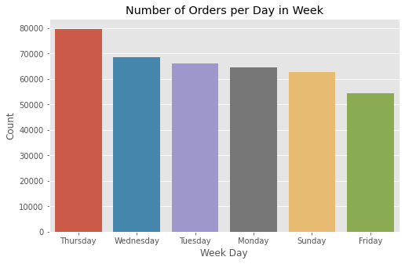

```python
order_per_day = pd.DataFrame(data.groupby(['WeekDay'])['InvoiceNo'].count())
order_per_day = order_per_day.reindex(['Monday', 'Tuesday', 'Wednesday', 'Thursday', 'Friday','Sunday'])
order_per_day = order_per_day.sort_values('InvoiceNo',ascending=False)

plt.figure(figsize=[8,5])
sns.barplot(data=order_per_day,x=order_per_day.index,y='InvoiceNo')
plt.title('Number of Orders per Day in Week')
plt.xlabel('Week Day')
plt.ylabel('Count')
plt.show()
```

We can see that most of orders on Thursday

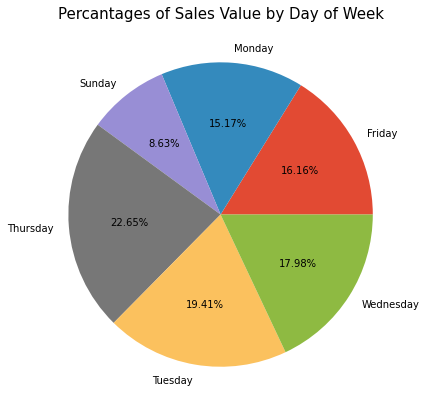

```python
#creating the pie chart
data.groupby('WeekDay')['revenue'].sum().plot(kind = 'pie', autopct = '%.2f%%', figsize=(7,7)).set(ylabel='')
plt.title('Percantages of Sales Value by Day of Week', fontsize = 15)
plt.show()
```

Also the higher revenue on Thursday

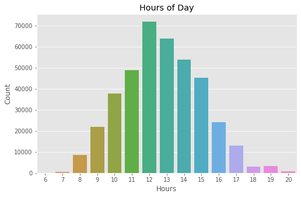

```python
order_per_hours = pd.DataFrame(data.groupby(['hour'])['InvoiceNo'].count()).reset_index()
order_per_hours = order_per_hours.sort_values('InvoiceNo',ascending=False)
plt.figure(figsize=[8,5])
sns.barplot(data=order_per_hours,x='hour',y='InvoiceNo')
plt.title("Hours of Day")
plt.xlabel('Hours')
plt.ylabel('Count')
plt.show()
```

We can see that people tend to make their orders at 12 and 13 and there is small number of order at 20

**Here we have a question about Which month brings the highest revenue? The next figure can answer this question**

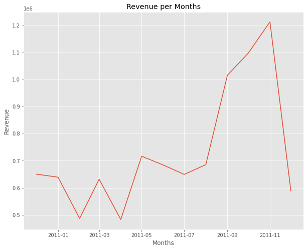

```python
highest_revenue = pd.DataFrame(data.groupby('month_year')['revenue'].sum()).reset_index()
plt.figure(figsize=[10,8])
sns.lineplot(data=highest_revenue,x='month_year',y='revenue')
plt.title('Revenue per Months')
plt.xlabel("Months")
plt.ylabel("Revenue")
plt.show()
```

**Of course, November is the highest in revenue because we saw earlier that it was the highest in seeling orders.**

Here we will go to the UnitPrice and explore it and try to get insight from it.

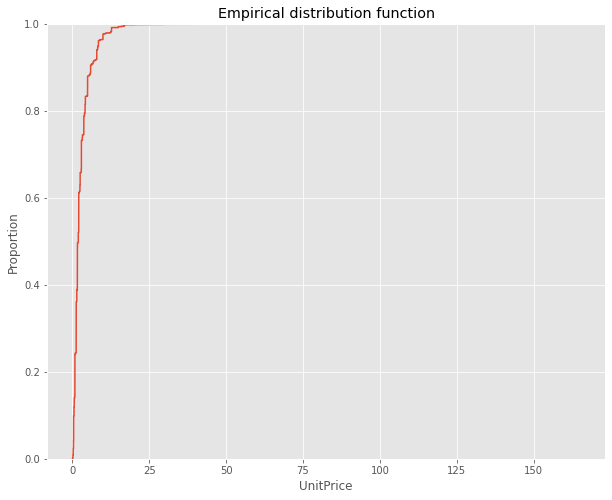

```python
plt.figure(figsize=[10,8])
sns.ecdfplot(data=df, x='UnitPrice')
plt.title("Empirical distribution function")
plt.xlabel("UnitPrice")
plt.ylabel("Proportion")
plt.show()
```

We can see that most of products have value less than 100 dollars (assume the currency is dollar)

```python
df[df['UnitPrice'] > 50]['Description'].unique().tolist()
```

```
['RUSTIC SEVENTEEN DRAWER SIDEBOARD',
 'CHALKBOARD KITCHEN ORGANISER',
 'VINTAGE POST OFFICE CABINET',
 'VINTAGE RED KITCHEN CABINET',
 'REGENCY MIRROR WITH SHUTTERS',
 'LOVE SEAT ANTIQUE WHITE METAL',
 'VINTAGE BLUE KITCHEN CABINET',
 'SCHOOL DESK AND CHAIR',
 'CHEST NATURAL WOOD 20 DRAWERS',
 'DECORATIVE HANGING SHELVING UNIT',
 'DOTCOMGIFTSHOP GIFT VOUCHER £10000']
```

These are the expensive products which the online retail sell it.

Next we will go to find the countries which buy these expensive products.

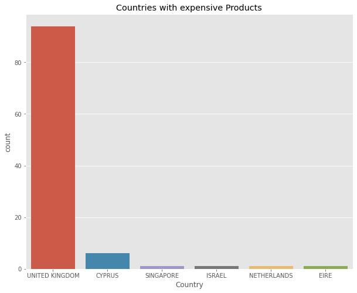

```python
plt.figure(figsize=[10,8])
sns.countplot(data=data[data['UnitPrice']>100], x='Country')
plt.title("Countries with expensive Products")
plt.xlabel('Country')
plt.show()
```

# Time Series Analysis

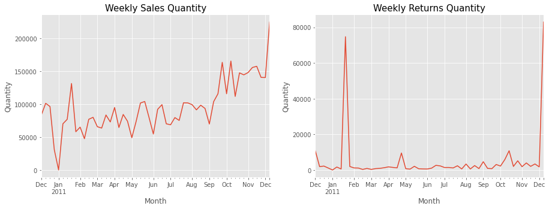

```python
cancel_trans.index = cancel_trans.InvoiceDate
data.index = data['InvoiceDate']
#resampling to get the weekly sales and returns
WeeklySale = data[data['Quantity']>0].Quantity.resample('W').sum()
WeeklyRet = cancel_trans[cancel_trans['Quantity']<0].Quantity.resample('W').sum().abs()

#creating the subplot
fig,[ax1, ax2] = plt.subplots(nrows=1,ncols=2, figsize = (15,5))

WeeklySale.plot(ax=ax1).set(xlabel="Month", ylabel="Quantity")
ax1.set_title("Weekly Sales Quantity", fontsize = 15)

WeeklyRet.plot(ax=ax2).set(xlabel="Month", ylabel="Quantity")
ax2.set_title("Weekly Returns Quantity", fontsize = 15)
plt.show()
```

In the next plot, we will use three features two show how the sales are distributed among different months and days of week.

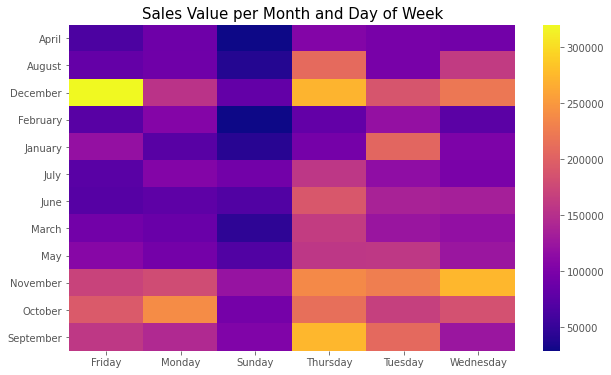

```python
tm_data = data.pivot_table(index = 'month_name',columns = 'WeekDay', values = 'revenue', aggfunc='sum')
plt.figure(figsize = (10,6))
sns.heatmap(tm_data, cmap = 'plasma').set(xlabel='', ylabel='')
plt.title('Sales Value per Month and Day of Week', fontsize = 15)
plt.show()
```

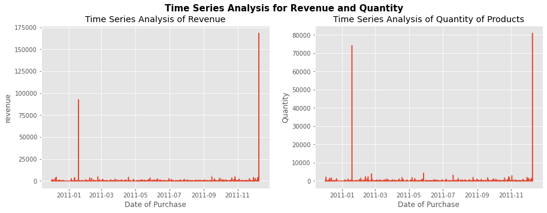

```python
fig,axs = plt.subplots(nrows=1,ncols=2,figsize= (15,5))
plt.subplots_adjust(hspace = 0.3)
fig.suptitle('Time Series Analysis for Revenue and Quantity', fontsize=15,fontweight = 'bold')

sns.lineplot(x =data.index ,y =data.revenue,ax=axs[0]).set_xlabel('Date of Purchase')
axs[0].set_title("Time Series Analysis of Revenue")

sns.lineplot(x = data.index, y =data.Quantity,ax=axs[1]).set_xlabel('Date of Purchase')
axs[1].set_title("Time Series Analysis of Quantity of Products")
plt.show()
```

# RFM

**We are going to analysis the Customers based on below 3 factors:**

Recency (R): Number of days since last purchase

Frequency (F): as total number of transactions

Monetary (M): as total money spent

```python
data.head()
```

| InvoiceDate | InvoiceNo | CustomerID | StockCode | Description | InvoiceDate | Quantity | UnitPrice | revenue | Country | month_name | month | year | month_year | WeekDay | hour |
| --- | --- | --- | --- | --- | --- | --- | --- | --- | --- | --- | --- | --- | --- | --- | --- |
| 2010-12-01 08:26:00 | 536365 | 17850.0 | 85123A | WHITE HANGING HEART T-LIGHT HOLDER | 2010-12-01 08:26:00 | 6 | 2.95 | 17.7 | UNITED KINGDOM | December | 12 | 2010 | 2010-12-01 | Wednesday | 8 |
| 2010-12-01 08:26:00 | 536365 | 17850.0 | 71053 | WHITE METAL LANTERN | 2010-12-01 08:26:00 | 6 | 3.75 | 22.5 | UNITED KINGDOM | December | 12 | 2010 | 2010-12-01 | Wednesday | 8 |
| 2010-12-01 08:26:00 | 536365 | 17850.0 | 84406B | CREAM CUPID HEARTS COAT HANGER | 2010-12-01 08:26:00 | 8 | 4.15 | 33.2 | UNITED KINGDOM | December | 12 | 2010 | 2010-12-01 | Wednesday | 8 |
| 2010-12-01 08:26:00 | 536365 | 17850.0 | 84029G | KNITTED UNION FLAG HOT WATER BOTTLE | 2010-12-01 08:26:00 | 6 | 3.75 | 22.5 | UNITED KINGDOM | December | 12 | 2010 | 2010-12-01 | Wednesday | 8 |
| 2010-12-01 08:26:00 | 536365 | 17850.0 | 84029E | RED WOOLLY HOTTIE WHITE HEART | 2010-12-01 08:26:00 | 6 | 4.25 | 25.5 | UNITED KINGDOM | December | 12 | 2010 | 2010-12-01 | Wednesday | 8 |

```python
#data= data.reset_index()
rfm_data=data[['CustomerID','InvoiceDate','InvoiceNo','Quantity','UnitPrice','revenue']]
rfm_data.head()
```

| InvoiceDate | CustomerID | InvoiceDate | InvoiceNo | Quantity | UnitPrice | revenue |
| --- | --- | --- | --- | --- | --- | --- |
| 2010-12-01 08:26:00 | 17850.0 | 2010-12-01 08:26:00 | 536365 | 6 | 2.95 | 17.7 |
| 2010-12-01 08:26:00 | 17850.0 | 2010-12-01 08:26:00 | 536365 | 6 | 3.75 | 22.5 |
| 2010-12-01 08:26:00 | 17850.0 | 2010-12-01 08:26:00 | 536365 | 8 | 4.15 | 33.2 |
| 2010-12-01 08:26:00 | 17850.0 | 2010-12-01 08:26:00 | 536365 | 6 | 3.75 | 22.5 |
| 2010-12-01 08:26:00 | 17850.0 | 2010-12-01 08:26:00 | 536365 | 6 | 4.25 | 25.5 |

Since this is a Recency, Frequency and Monetary Table, grouping is done based on each CustomerID. Our goal is to group by CustomerID, then calculate how far back the customer made their last purchase, howw often the customer made a purchase from our site and the total amount spent by each customer.

```python
max_date = max(rfm_data['InvoiceDate'])
```

```python
rfm = rfm_data.groupby(['CustomerID']).agg({'InvoiceDate': lambda x : (max_date - x.max()).days,
                                      'InvoiceNo': 'count',
                                      'revenue': 'sum'})
rfm.rename(columns={'InvoiceDate':'Recency', 'InvoiceNo':'Frequency', 'revenue':'Monetary'}
           ,inplace= True)
rfm.head()
```

| CustomerID | Recency | Frequency | Monetary |
| --- | --- | --- | --- |
| 12346.0 | 325 | 1 | 92768.75 |
| 12347.0 | 1 | 182 | 4626.38 |
| 12348.0 | 74 | 27 | 1499.64 |
| 12349.0 | 18 | 72 | 1450.95 |
| 12350.0 | 309 | 16 | 321.16 |

**We can now segment the data based on our requirements. We'll divide the rfm data into 4 quantiles and assign them a label between 1 and 4. This should help us score each customer and bringing things down to one number can help simplyfying your segmentation process.**

**Computing Quantile of RFM values**

Customers with the lowest recency, highest frequency and monetary amounts considered as top customers.

```python
#Building RFM segments
r_labels = range(4, 0, -1)
r_groups = pd.qcut(rfm.Recency, q = 4, labels = r_labels)
f_labels = range(1, 5)
f_groups = pd.qcut(rfm.Frequency, q = 4, labels = f_labels)
m_labels = range(1, 5)
m_groups = pd.qcut(rfm.Monetary, q = 4, labels = m_labels)

# make a new column for group labels
rfm['R'] = r_groups.values
rfm['F'] = f_groups.values
rfm['M'] = m_groups.values
```

```python
rfm.head(2)
```

| CustomerID | Recency | Frequency | Monetary | R | F | M |
| --- | --- | --- | --- | --- | --- | --- |
| 12346.0 | 325 | 1 | 92768.75 | 1 | 1 | 4 |
| 12347.0 | 1 | 182 | 4626.38 | 4 | 4 | 4 |

**RFM Result Interpretation**

Combine all three quartiles(r_quartile,f_quartile,m_quartile) in a single column, this rank will help you to segment the customers well group.

```python
# sum up the three columns
rfm['RFM_Segment'] = rfm.R.astype(str)+ rfm.F.astype(str) + rfm.M.astype(str)
rfm['RFM_Score'] = rfm[['R', 'F', 'M']].sum(axis = 1)
rfm.head()
```

| CustomerID | Recency | Frequency | Monetary | R | F | M | RFM_Segment | RFM_Score |
| --- | --- | --- | --- | --- | --- | --- | --- | --- |
| 12346.0 | 325 | 1 | 92768.75 | 1 | 1 | 4 | 114 | 6 |
| 12347.0 | 1 | 182 | 4626.38 | 4 | 4 | 4 | 444 | 12 |
| 12348.0 | 74 | 27 | 1499.64 | 2 | 2 | 3 | 223 | 7 |
| 12349.0 | 18 | 72 | 1450.95 | 3 | 3 | 3 | 333 | 9 |
| 12350.0 | 309 | 16 | 321.16 | 1 | 1 | 2 | 112 | 4 |

```python
# calculate averae values for each RFM
rfm_agg = rfm.groupby('RFM_Score')\
    .agg({'Recency' : 'mean',
        'Frequency' : 'mean',
        'Monetary' : ['mean', 'count']
})
rfm_agg.round(1)
```

| RFM_Score | Recency mean | Frequency mean | Monetary mean | Monetary count |
| --- | --- | --- | --- | --- |
| 3 | 260.8 | 8.3 | 163.3 | 383 |
| 4 | 174.6 | 14.0 | 243.1 | 387 |
| 5 | 152.9 | 21.4 | 380.4 | 508 |
| 6 | 97.3 | 27.8 | 803.2 | 466 |
| 7 | 79.5 | 39.3 | 782.1 | 447 |
| 8 | 62.6 | 56.6 | 1036.1 | 471 |
| 9 | 44.1 | 78.4 | 1884.7 | 417 |
| 10 | 30.6 | 114.8 | 2139.8 | 423 |
| 11 | 20.1 | 186.2 | 4362.0 | 386 |
| 12 | 6.2 | 373.6 | 10322.4 | 446 |

RFM_Score will be the total score of a customer’s engagement or loyalty. Summing up the three values altogether, we can finally categorize customers into ‘Gold,’ ‘Silver,’ ‘Bronze,’ and ‘Green’.

```python
# assign labels from total score
score_labels = ['Green', 'Bronze', 'Silver', 'Gold']
score_groups = pd.qcut(rfm.RFM_Score, q = 4, labels = score_labels)
rfm['RFM_Level'] = score_groups.values
rfm.head()
```

| CustomerID | Recency | Frequency | Monetary | R | F | M | RFM_Segment | RFM_Score | RFM_Level |
| --- | --- | --- | --- | --- | --- | --- | --- | --- | --- |
| 12346.0 | 325 | 1 | 92768.75 | 1 | 1 | 4 | 114 | 6 | Bronze |
| 12347.0 | 1 | 182 | 4626.38 | 4 | 4 | 4 | 444 | 12 | Gold |
| 12348.0 | 74 | 27 | 1499.64 | 2 | 2 | 3 | 223 | 7 | Bronze |
| 12349.0 | 18 | 72 | 1450.95 | 3 | 3 | 3 | 333 | 9 | Silver |
| 12350.0 | 309 | 16 | 321.16 | 1 | 1 | 2 | 112 | 4 | Green |

We can see the number of customers at each segment or level

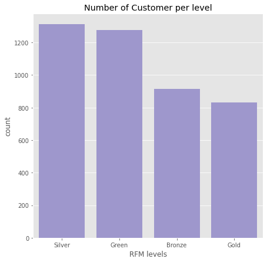

```python
plt.figure(figsize=[7,7])
rfm_lev = rfm['RFM_Level'].value_counts().index
sns.countplot(data=rfm,x='RFM_Level',order=rfm_lev,color=sns.color_palette()[2])
plt.title("Number of Customer per level")
plt.xlabel("RFM levels")
plt.show()
```

# K-Means Clustering

Because K-means clustering uses the distance as the similarity factor, we need to scale the data.

```python
#reset index and extract necessary columns
rfm = rfm.reset_index()
rfm_km = rfm[['Recency','Frequency','Monetary']]
rfm_km.head()
```

|  | Recency | Frequency | Monetary |
| --- | --- | --- | --- |
| 0 | 325 | 1 | 92768.75 |
| 1 | 1 | 182 | 4626.38 |
| 2 | 74 | 27 | 1499.64 |
| 3 | 18 | 72 | 1450.95 |
| 4 | 309 | 16 | 321.16 |

```python
# define function for the values equal 0
def val_eql_zero(x):
    if x <= 0:
        return 1
    else:
        return x
```

```python
# apply the function to Recency column to omit 0
rfm_km['Recency'] = [val_eql_zero(x) for x in rfm_km.Recency]
# unskew the data
rfm_log = rfm_km[['Recency', 'Frequency', 'Monetary']].apply(np.log, axis = 1).round(3)
```

```python
# scale the data
scaler = StandardScaler()
rfm_scaled = scaler.fit_transform(rfm_log)
```

```python
# transform into a dataframe
rfm_scaled = pd.DataFrame(rfm_scaled, index = rfm.index, columns = rfm_log.columns)
rfm_scaled.head()
```

|  | Recency | Frequency | Monetary |
| --- | --- | --- | --- |
| 0 | 1.372190 | -2.771931 | 3.792454 |
| 1 | -2.451749 | 1.152049 | 1.435115 |
| 2 | 0.393727 | -0.286643 | 0.548950 |
| 3 | -0.541101 | 0.453062 | 0.523002 |
| 4 | 1.338473 | -0.681002 | -0.662744 |

In the next plot we can see the difference in the shape of data after Preprocessing and Normalization

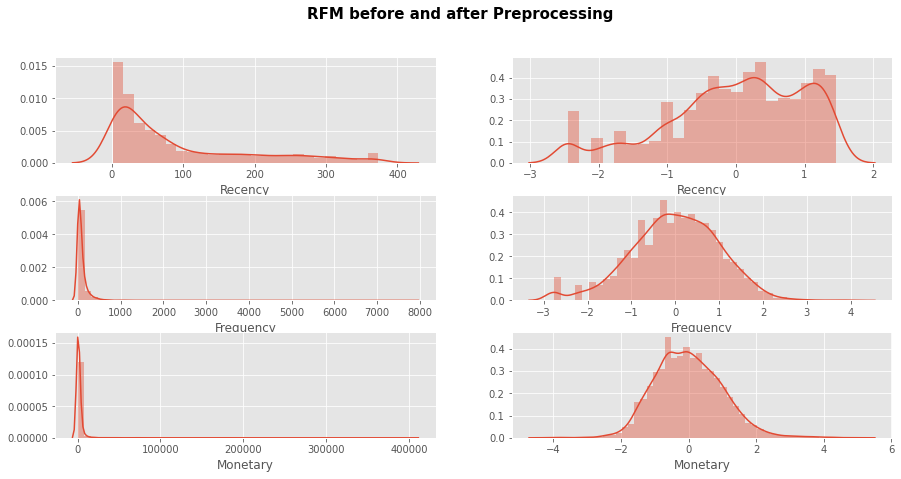

```python
fig,axs = plt.subplots(nrows=3,ncols = 2,figsize= (15,7))
plt.subplots_adjust(hspace = 0.3)
fig.suptitle('RFM before and after Preprocessing', fontsize=15,fontweight = 'bold')


sns.distplot(rfm_km.Recency,kde=True,ax=axs[0,0]).set_ylabel('')
sns.distplot(rfm_km.Frequency,kde=True,ax=axs[1,0]).set_ylabel("")
sns.distplot(rfm_km.Monetary,kde=True,ax=axs[2,0]).set_ylabel("")

sns.distplot(rfm_scaled.Recency,kde=True,ax=axs[0,1]).set_ylabel("")
sns.distplot(rfm_scaled.Frequency,kde=True,ax=axs[1,1]).set_ylabel("")
sns.distplot(rfm_scaled.Monetary,kde=True,ax=axs[2,1]).set_ylabel("")

plt.show()
```

**NOW we will go to famous and familier Unsupervisd learning Algorithm K-MEANS**

We will use Elbow method to determine the optimal number of clusters

```python
ssd = []
for i in range(1,11):
    kmeans = KMeans(n_clusters = i,init= 'k-means++', max_iter=300)
    kmeans.fit(rfm_scaled)

    ssd.append(kmeans.inertia_)
```

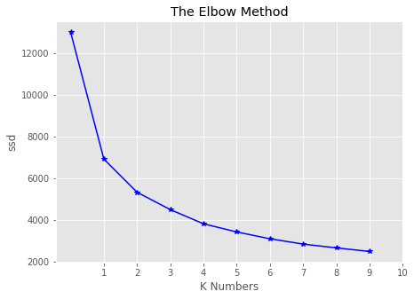

```python
plt.figure(figsize=[7,5])
plt.plot(ssd,'b*-')
plt.title('The Elbow Method')
plt.xticks(range(1,11))
plt.xlabel('K Numbers')
plt.ylabel('ssd')
plt.show()
```

**According to the elbow method we will choose the n_cluster = 3**

```python
#clustering
clust = KMeans(n_clusters =3,init= 'k-means++',max_iter=300)
clust.fit(rfm_scaled)
```

```
KMeans(n_clusters=3)
```

```python
# assign clusters to rfm
rfm['Cluster'] = clust.labels_
rfm_scaled['Cluster'] = clust.labels_
rfm.set_index('CustomerID')
rfm.head()
```

|  | CustomerID | Recency | Frequency | Monetary | R | F | M | RFM_Segment | RFM_Score | RFM_Level | Cluster |
| --- | --- | --- | --- | --- | --- | --- | --- | --- | --- | --- | --- |
| 0 | 12346.0 | 325 | 1 | 92768.75 | 1 | 1 | 4 | 114 | 6 | Bronze | 2 |
| 1 | 12347.0 | 1 | 182 | 4626.38 | 4 | 4 | 4 | 444 | 12 | Gold | 1 |
| 2 | 12348.0 | 74 | 27 | 1499.64 | 2 | 2 | 3 | 223 | 7 | Bronze | 2 |
| 3 | 12349.0 | 18 | 72 | 1450.95 | 3 | 3 | 3 | 333 | 9 | Silver | 2 |
| 4 | 12350.0 | 309 | 16 | 321.16 | 1 | 1 | 2 | 112 | 4 | Green | 0 |

```python
# number of customers in each cluster
market_km = rfm_scaled.Cluster.value_counts()
```

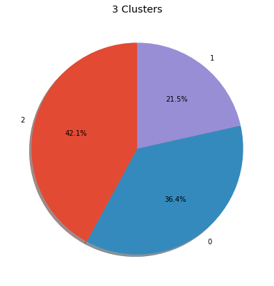

```python
fig = plt.figure(figsize=(20,7))
plt.title('3 Clusters')
plt.pie(market_km,labels=market_km.index, autopct='%1.1f%%', shadow=True, startangle=90)
plt.show()
```

In the next figure we will see the cluster with the RFM

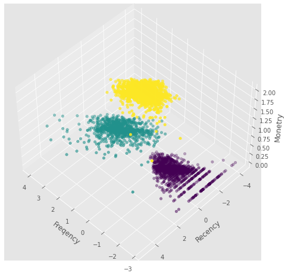

```python
fig = plt.figure(1, figsize=(10, 6))

ax = Axes3D(fig, rect=[0, 0, .95, 1], elev=48, azim=134)
ax.set_xlabel('Freqency')
ax.set_ylabel('Recency')
ax.set_zlabel('Monetry')

ax.scatter(rfm_scaled.iloc[:, 1], rfm_scaled.iloc[:, 2], rfm_scaled.iloc[:, 3],c=rfm_scaled['Cluster'])
plt.show()
```

We will explore RFM for each cluster and see properties for each one

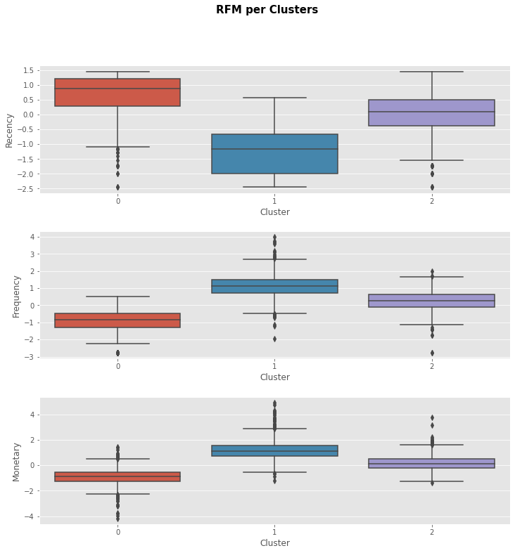

```python
fig,axs = plt.subplots(3,1,figsize=[12,12])
plt.subplots_adjust(hspace = 0.3)
fig.suptitle('RFM per Clusters', fontsize=15,fontweight = 'bold')

sns.boxplot(x=rfm_scaled.Cluster,y=rfm_scaled.Recency,ax=axs[0])
sns.boxplot(x=rfm_scaled.Cluster,y=rfm_scaled.Frequency,ax=axs[1])
sns.boxplot(x=rfm_scaled.Cluster,y=rfm_scaled.Monetary,ax=axs[2])

plt.show()
```

**From the previous plots**,

we can see that Cluster 0 customers are considered old customers,which they have very high recency and low frequancy and monetry, we can say that ordered from long time ago number of orders and with small amount of money.

while as, Cluster 1 we can consider them our loyal customers, also Cluster 2 is between them.

**Cluster 0 Properties:** Big recency, small Frequency ,small Monetry

**Cluster 1 Properties:** Small recency, big Frequency ,big Monetry

**Cluster 2 Properties:** medium recency, medium Frequency ,medium Monetry

Now we made two kinds of segmentation, RFM quantile groups and K-Means groups. Let’s make visualization and compare the two methods.

```python
rfm.head(2)
```

|  | CustomerID | Recency | Frequency | Monetary | R | F | M | RFM_Segment | RFM_Score | RFM_Level | Cluster |
| --- | --- | --- | --- | --- | --- | --- | --- | --- | --- | --- | --- |
| 0 | 12346.0 | 325 | 1 | 92768.75 | 1 | 1 | 4 | 114 | 6 | Bronze | 2 |
| 1 | 12347.0 | 1 | 182 | 4626.38 | 4 | 4 | 4 | 444 | 12 | Gold | 1 |

```python
# the mean value in total
total_avg = rfm.iloc[:, 1:4].mean()
total_avg
# calculate the proportional gap with total mean
cluster_avg = rfm.groupby('RFM_Level').mean().iloc[:, 1:4]
prop_rfm = cluster_avg/total_avg - 1

# calculate the proportional gap with total mean
cluster_avg_K = rfm.groupby('Cluster').mean().iloc[:, 1:4]
prop_rfm_K = cluster_avg_K/total_avg - 1
```

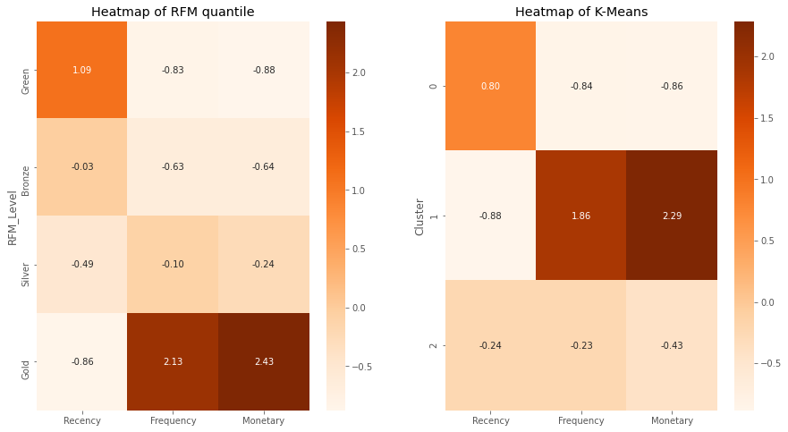

```python
fig,axs= plt.subplots(nrows=1,ncols=2,figsize=(15,8))
# heatmap with RFM
sns.heatmap(prop_rfm, cmap= 'Oranges', fmt= '.2f', annot = True,ax=axs[0])
axs[0].set_title('Heatmap of RFM quantile')

# heatmap with K-means
sns.heatmap(prop_rfm_K, cmap= 'Oranges', fmt= '.2f', annot = True,ax=axs[1])
axs[1].set_title('Heatmap of K-Means')
plt.show()
```

It could be seen unmatching, especially at the top of the plots. But It’s just because of the different order.

# Conclusion

**We talked about how to get RFM values from customer purchase data, and we made two kinds of segmentation with RFM quantiles and K-Means clustering methods. With this result, we can now figure out who are our ‘golden’ customers, the most profitable groups. This also tells us on which customer to focus on and to whom give special offers or promotions for fostering loyalty among customers. We can select the best communication channel for each segment and improve new marketing strategies.**